# Project: Investigate a Dataset (Medical Appointment No Shows)

- Introduction
- Data Wrangling
- Exploratory Data Analysis
- Conclusions

## Introduction

### Dataset Description

This dataset collects information from 100k medical appointments in Brazil and is focused on the question of whether

or not patients show up for their appointment. Several of characteristics of the patient are included in each row.

Be careful about the encoding of the last column: it says ‘No’ if the patient showed up to their appointment, and ‘Yes’ if they did not show up.

### Question(s) for Analysis:

1- Does receiving an SMS affect showing up for the appointment?

2- Is there a correlation between having a scholarship and showing up for the appointment?

3- Is there a correlation between having Hypertension and showing up for the appointment?

4- Is there a correlation between having diabetes and showing up for the appointment?

5- Is there a correlation between drinking alcoholism and showing up for the appointment?

6- Is there a correlation between having a handicap and showing up for the appointment?

7- Is there a correlation between gender and showing up for the appointment?

8- Is age affect showing up for the appointment?

9- Is age and having diseases affect showing up for the appointment?

10- Is age and having handicaps affect in showing up for the appointment?

```python
# importing all the necessary packages
import pandas as pd
import numpy as np
import matplotlib.pyplot as plt
import seaborn as sns
%matplotlib inline
```

## Data Wrangling

### General Properties

```python
# Load data and print out a few lines. Perform operations to inspect data
# types and look for instances of missing or possibly errant data.
df = pd.read_csv('noshowappointments-kagglev2-may-2016.csv')
df.head()
```

|  | PatientId | AppointmentID | Gender | ScheduledDay | AppointmentDay | Age | Neighbourhood | Scholarship | Hipertension | Diabetes | Alcoholism | Handcap | SMS_received | No-show |
| --- | --- | --- | --- | --- | --- | --- | --- | --- | --- | --- | --- | --- | --- | --- |
| 0 | 2.987250e+13 | 5642903 | F | 2016-04-29T18:38:08Z | 2016-04-29T00:00:00Z | 62 | JARDIM DA PENHA | 0 | 1 | 0 | 0 | 0 | 0 | No |
| 1 | 5.589978e+14 | 5642503 | M | 2016-04-29T16:08:27Z | 2016-04-29T00:00:00Z | 56 | JARDIM DA PENHA | 0 | 0 | 0 | 0 | 0 | 0 | No |
| 2 | 4.262962e+12 | 5642549 | F | 2016-04-29T16:19:04Z | 2016-04-29T00:00:00Z | 62 | MATA DA PRAIA | 0 | 0 | 0 | 0 | 0 | 0 | No |
| 3 | 8.679512e+11 | 5642828 | F | 2016-04-29T17:29:31Z | 2016-04-29T00:00:00Z | 8 | PONTAL DE CAMBURI | 0 | 0 | 0 | 0 | 0 | 0 | No |
| 4 | 8.841186e+12 | 5642494 | F | 2016-04-29T16:07:23Z | 2016-04-29T00:00:00Z | 56 | JARDIM DA PENHA | 0 | 1 | 1 | 0 | 0 | 0 | No |

```python
# number of rows and cloumns
df.shape
```

```
(110527, 14)
```

```python
# some information about columns in data
df.info()
```

```
<class 'pandas.core.frame.DataFrame'>
RangeIndex: 110527 entries, 0 to 110526
Data columns (total 14 columns):
 #   Column          Non-Null Count   Dtype
---  ------          --------------   -----
 0   PatientId       110527 non-null  float64
 1   AppointmentID   110527 non-null  int64
 2   Gender          110527 non-null  object
 3   ScheduledDay    110527 non-null  object
 4   AppointmentDay  110527 non-null  object
 5   Age             110527 non-null  int64
 6   Neighbourhood   110527 non-null  object
 7   Scholarship     110527 non-null  int64
 8   Hipertension    110527 non-null  int64
 9   Diabetes        110527 non-null  int64
 10  Alcoholism      110527 non-null  int64
 11  Handcap         110527 non-null  int64
 12  SMS_received    110527 non-null  int64
 13  No-show         110527 non-null  object
dtypes: float64(1), int64(8), object(5)
memory usage: 11.8+ MB
```

It seems that the name of some columns is not correct also the type has to change for some columns.

```python
# number of nulls in each column
df.isnull().sum()
```

```
PatientId         0
AppointmentID     0
Gender            0
ScheduledDay      0
AppointmentDay    0
Age               0
Neighbourhood     0
Scholarship       0
Hipertension      0
Diabetes          0
Alcoholism        0
Handcap           0
SMS_received      0
No-show           0
dtype: int64
```

```python
df.duplicated().sum()
```

```
0
```

There are no duplicated rows or any missing values.

```python
df.describe()
```

|  | PatientId | AppointmentID | Age | Scholarship | Hipertension | Diabetes | Alcoholism | Handcap | SMS_received |
| --- | --- | --- | --- | --- | --- | --- | --- | --- | --- |
| count | 1.105270e+05 | 1.105270e+05 | 110527.000000 | 110527.000000 | 110527.000000 | 110527.000000 | 110527.000000 | 110527.000000 | 110527.000000 |
| mean | 1.474963e+14 | 5.675305e+06 | 37.088874 | 0.098266 | 0.197246 | 0.071865 | 0.030400 | 0.022248 | 0.321026 |
| std | 2.560949e+14 | 7.129575e+04 | 23.110205 | 0.297675 | 0.397921 | 0.258265 | 0.171686 | 0.161543 | 0.466873 |
| min | 3.921784e+04 | 5.030230e+06 | -1.000000 | 0.000000 | 0.000000 | 0.000000 | 0.000000 | 0.000000 | 0.000000 |
| 25% | 4.172614e+12 | 5.640286e+06 | 18.000000 | 0.000000 | 0.000000 | 0.000000 | 0.000000 | 0.000000 | 0.000000 |
| 50% | 3.173184e+13 | 5.680573e+06 | 37.000000 | 0.000000 | 0.000000 | 0.000000 | 0.000000 | 0.000000 | 0.000000 |
| 75% | 9.439172e+13 | 5.725524e+06 | 55.000000 | 0.000000 | 0.000000 | 0.000000 | 0.000000 | 0.000000 | 1.000000 |
| max | 9.999816e+14 | 5.790484e+06 | 115.000000 | 1.000000 | 1.000000 | 1.000000 | 1.000000 | 4.000000 | 1.000000 |

There are incorrect data and outliers in age.

### Data Cleaning (Fixing some problems in data)

```python
# Rename the incorrect columns
df.rename(columns={'Hipertension': 'Hypertension', 'Handcap': 'Handicap', 'SMS_received':'SMSReceived', 'No-show':'NoShow'}, inplace=True)
df.head()
```

|  | PatientId | AppointmentID | Gender | ScheduledDay | AppointmentDay | Age | Neighbourhood | Scholarship | Hypertension | Diabetes | Alcoholism | Handicap | SMSReceived | NoShow |
| --- | --- | --- | --- | --- | --- | --- | --- | --- | --- | --- | --- | --- | --- | --- |
| 0 | 2.987250e+13 | 5642903 | F | 2016-04-29T18:38:08Z | 2016-04-29T00:00:00Z | 62 | JARDIM DA PENHA | 0 | 1 | 0 | 0 | 0 | 0 | No |
| 1 | 5.589978e+14 | 5642503 | M | 2016-04-29T16:08:27Z | 2016-04-29T00:00:00Z | 56 | JARDIM DA PENHA | 0 | 0 | 0 | 0 | 0 | 0 | No |
| 2 | 4.262962e+12 | 5642549 | F | 2016-04-29T16:19:04Z | 2016-04-29T00:00:00Z | 62 | MATA DA PRAIA | 0 | 0 | 0 | 0 | 0 | 0 | No |
| 3 | 8.679512e+11 | 5642828 | F | 2016-04-29T17:29:31Z | 2016-04-29T00:00:00Z | 8 | PONTAL DE CAMBURI | 0 | 0 | 0 | 0 | 0 | 0 | No |
| 4 | 8.841186e+12 | 5642494 | F | 2016-04-29T16:07:23Z | 2016-04-29T00:00:00Z | 56 | JARDIM DA PENHA | 0 | 1 | 1 | 0 | 0 | 0 | No |

```python
# finding out the rows that have the incorrect data in age
df.query('Age < 0')
```

|  | PatientId | AppointmentID | Gender | ScheduledDay | AppointmentDay | Age | Neighbourhood | Scholarship | Hypertension | Diabetes | Alcoholism | Handicap | SMSReceived | NoShow |
| --- | --- | --- | --- | --- | --- | --- | --- | --- | --- | --- | --- | --- | --- | --- |
| 99832 | 4.659432e+14 | 5775010 | F | 2016-06-06T08:58:13Z | 2016-06-06T00:00:00Z | -1 | ROMÃO | 0 | 0 | 0 | 0 | 0 | 0 | No |

```python
# Remove the incorrect data of age
df.drop(index=99832, inplace=True)
```

```python
# finding out the rows that have the outliers in age
df.query('Age > 100')
```

|  | PatientId | AppointmentID | Gender | ScheduledDay | AppointmentDay | Age | Neighbourhood | Scholarship | Hypertension | Diabetes | Alcoholism | Handicap | SMSReceived | NoShow |
| --- | --- | --- | --- | --- | --- | --- | --- | --- | --- | --- | --- | --- | --- | --- |
| 58014 | 9.762948e+14 | 5651757 | F | 2016-05-03T09:14:53Z | 2016-05-03T00:00:00Z | 102 | CONQUISTA | 0 | 0 | 0 | 0 | 0 | 0 | No |
| 63912 | 3.196321e+13 | 5700278 | F | 2016-05-16T09:17:44Z | 2016-05-19T00:00:00Z | 115 | ANDORINHAS | 0 | 0 | 0 | 0 | 1 | 0 | Yes |
| 63915 | 3.196321e+13 | 5700279 | F | 2016-05-16T09:17:44Z | 2016-05-19T00:00:00Z | 115 | ANDORINHAS | 0 | 0 | 0 | 0 | 1 | 0 | Yes |
| 68127 | 3.196321e+13 | 5562812 | F | 2016-04-08T14:29:17Z | 2016-05-16T00:00:00Z | 115 | ANDORINHAS | 0 | 0 | 0 | 0 | 1 | 0 | Yes |
| 76284 | 3.196321e+13 | 5744037 | F | 2016-05-30T09:44:51Z | 2016-05-30T00:00:00Z | 115 | ANDORINHAS | 0 | 0 | 0 | 0 | 1 | 0 | No |
| 90372 | 2.342836e+11 | 5751563 | F | 2016-05-31T10:19:49Z | 2016-06-02T00:00:00Z | 102 | MARIA ORTIZ | 0 | 0 | 0 | 0 | 0 | 0 | No |
| 97666 | 7.482346e+14 | 5717451 | F | 2016-05-19T07:57:56Z | 2016-06-03T00:00:00Z | 115 | SÃO JOSÉ | 0 | 1 | 0 | 0 | 0 | 1 | No |

```python
# Remove the outliers of age
df.drop(index=58014, inplace=True)
df.drop(index=63912, inplace=True)
df.drop(index=63915, inplace=True)
df.drop(index=68127, inplace=True)
df.drop(index=76284, inplace=True)
df.drop(index=90372, inplace=True)
df.drop(index=97666, inplace=True)
```

```python
# make sure that we removed the incorrect data and the outliers
df.query('Age > 100')
```

|  | PatientId | AppointmentID | Gender | ScheduledDay | AppointmentDay | Age | Neighbourhood | Scholarship | Hypertension | Diabetes | Alcoholism | Handicap | SMSReceived | NoShow |
| --- | --- | --- | --- | --- | --- | --- | --- | --- | --- | --- | --- | --- | --- | --- |

```python
df.query('Age < 0')
```

|  | PatientId | AppointmentID | Gender | ScheduledDay | AppointmentDay | Age | Neighbourhood | Scholarship | Hypertension | Diabetes | Alcoholism | Handicap | SMSReceived | NoShow |
| --- | --- | --- | --- | --- | --- | --- | --- | --- | --- | --- | --- | --- | --- | --- |

```python
df.describe()
```

|  | PatientId | AppointmentID | Age | Scholarship | Hypertension | Diabetes | Alcoholism | Handicap | SMSReceived |
| --- | --- | --- | --- | --- | --- | --- | --- | --- | --- |
| count | 1.105190e+05 | 1.105190e+05 | 110519.000000 | 110519.000000 | 110519.000000 | 110519.000000 | 110519.000000 | 110519.000000 | 110519.000000 |
| mean | 1.474860e+14 | 5.675303e+06 | 37.084519 | 0.098273 | 0.197251 | 0.071870 | 0.030402 | 0.022213 | 0.321040 |
| std | 2.560826e+14 | 7.129600e+04 | 23.103165 | 0.297684 | 0.397925 | 0.258274 | 0.171692 | 0.161441 | 0.466878 |
| min | 3.921784e+04 | 5.030230e+06 | 0.000000 | 0.000000 | 0.000000 | 0.000000 | 0.000000 | 0.000000 | 0.000000 |
| 25% | 4.172457e+12 | 5.640284e+06 | 18.000000 | 0.000000 | 0.000000 | 0.000000 | 0.000000 | 0.000000 | 0.000000 |
| 50% | 3.172598e+13 | 5.680569e+06 | 37.000000 | 0.000000 | 0.000000 | 0.000000 | 0.000000 | 0.000000 | 0.000000 |
| 75% | 9.438963e+13 | 5.725522e+06 | 55.000000 | 0.000000 | 0.000000 | 0.000000 | 0.000000 | 0.000000 | 1.000000 |
| max | 9.999816e+14 | 5.790484e+06 | 100.000000 | 1.000000 | 1.000000 | 1.000000 | 1.000000 | 4.000000 | 1.000000 |

```python
# dropping colunms that I don't need in my analysis
df.drop(['PatientId','AppointmentID','ScheduledDay','AppointmentDay'], axis = 1, inplace =True )
df.head()
```

|  | Gender | Age | Neighbourhood | Scholarship | Hypertension | Diabetes | Alcoholism | Handicap | SMSReceived | NoShow |
| --- | --- | --- | --- | --- | --- | --- | --- | --- | --- | --- |
| 0 | F | 62 | JARDIM DA PENHA | 0 | 1 | 0 | 0 | 0 | 0 | No |
| 1 | M | 56 | JARDIM DA PENHA | 0 | 0 | 0 | 0 | 0 | 0 | No |
| 2 | F | 62 | MATA DA PRAIA | 0 | 0 | 0 | 0 | 0 | 0 | No |
| 3 | F | 8 | PONTAL DE CAMBURI | 0 | 0 | 0 | 0 | 0 | 0 | No |
| 4 | F | 56 | JARDIM DA PENHA | 0 | 1 | 1 | 0 | 0 | 0 | No |

## Exploratory Data Analysis

Now that the data has been cleaned, let's try to answer the questions we brought it up before.

### General Vision

```
array([[<AxesSubplot:title={'center':'Age'}>,
        <AxesSubplot:title={'center':'Scholarship'}>,
        <AxesSubplot:title={'center':'Hypertension'}>],
       [<AxesSubplot:title={'center':'Diabetes'}>,
        <AxesSubplot:title={'center':'Alcoholism'}>,
        <AxesSubplot:title={'center':'Handicap'}>],
       [<AxesSubplot:title={'center':'SMSReceived'}>, <AxesSubplot:>,
        <AxesSubplot:>]], dtype=object)
```

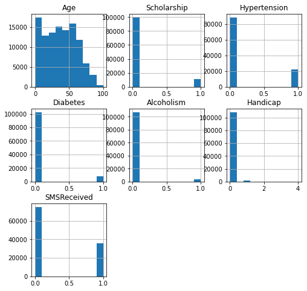

```python
# let's take a general vision of our data
df.hist(figsize=(8, 8))
```

```python
# number of patients who show up for their appointment and who didn't show up
df.NoShow.value_counts()
```

```
No     88203
Yes    22316
Name: NoShow, dtype: int64
```

The number of patients who show up to their appointments is 88203 and those who didn't show is 22316.

```python
# divide the patients into 2 groups show and no_show
show = df.NoShow == 'No'
no_show = df.NoShow == 'Yes'
```

### Research Question 1 (Does receiving an SMS affect showing up for the appointment?)

By answering this question we will discover if we have to send an SMS to every patient to confirm his attendance or it is not that important.

```python
# number of patients who received an SMS and who didn't receive anything
df.SMSReceived.value_counts()
```

```
0    75038
1    35481
Name: SMSReceived, dtype: int64
```

There were 35481 patients who received an SMS and 75038 didn't receive an SMS.

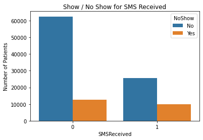

```python
# finding out the correlation between receiving an SMS and showing up for the appointment
def chart_plot(var1, chart_title):
    ax = sns.countplot(x=var1, hue='NoShow', data=df)
    ax.set(xlabel=var1, ylabel='Number of Patients', title=chart_title)

chart_plot('SMSReceived', 'Show / No Show for SMS Received')
```

It seems like the number of patients who showed up for the appointment and didn't receive an SMS was greater than those who received an SMS.

### Research Question 2 (Is there a correlation between having a scholarship and showing up for the appointment?)

By answering this question we will discover if most of our patients attend the appointment because of the scholarship or not.

```python
# number of patients who having a scholarship and who didn't have it
df.Scholarship.value_counts()
```

```
0    99658
1    10861
Name: Scholarship, dtype: int64
```

Most of the patients didn't have a scholarship.

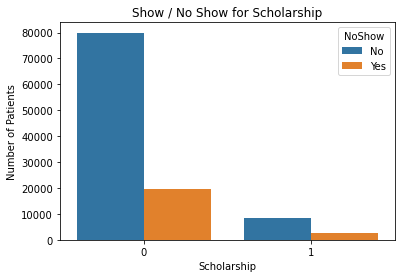

```python
# finding out the correlation between having a scholarship and showing up for the appointment
chart_plot('Scholarship', 'Show / No Show for Scholarship')
```

It is clear that the patients who had not a scholarship showed up for the appointment more than those who had it.

### Research Question 3 (Is there a correlation between having Hypertension and showing up for the appointment?)

By answering this question we will discover if having a disease like hypertension affect showing up for the appointment.

```python
# number of patients who having hypertension and who didn't have it
df.Hypertension.value_counts()
```

```
0    88719
1    21800
Name: Hypertension, dtype: int64
```

Most of the patients didn't have hypertension.

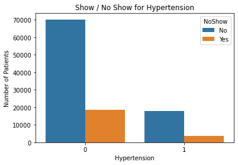

```python
# finding out the correlation between having hypertension and showing up for the appointment
chart_plot('Hypertension', 'Show / No Show for Hypertension')
```

The number of patients who showed up and didn't have hypertension was more than the number of patients who showed up and have hypertension but also we have to consider that the number of patients who did have not hypertension was almost 4 times the number of patients who have hypertension.

### Research Question 4 (Is there a correlation between having diabetes and showing up for the appointment?)

By answering this question we will discover if having a disease like diabetes affect showing up for the appointment.

```python
# number of patients who having diabetes and who didn't have it
df.Diabetes.value_counts()
```

```
0    102576
1      7943
Name: Diabetes, dtype: int64
```

Most of the patients didn't have diabetes.

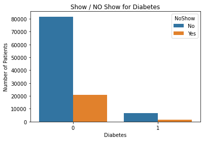

```python
# finding out the correlation between having diabetes and showing up for the appointment
chart_plot('Diabetes', 'Show / NO Show for Diabetes')
```

The number of patients who showed up and didn't have diabetes was much more than the number of patients who showed up and have diabetes but also we have to consider that the number of patients who did have not diabetes was about 13 times the number of patients who have diabetes.

### Research Question 5 (Is there a correlation between drinking alcoholism and showing up for the appointment?)

By answering this question we will discover if the patients who were drinking alcoholism were more likely to not attend the appointment or not.

```python
# number of patients who were drinking alcoholism and who didn't drink it
df.Alcoholism.value_counts()
```

```
0    107159
1      3360
Name: Alcoholism, dtype: int64
```

Most of the patients were not drinking alcoholism.

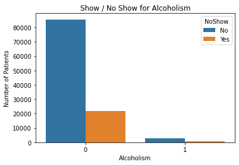

```python
# finding out the correlation between drinking alcoholism and showing up for the appointment
chart_plot('Alcoholism', 'Show / No Show for Alcoholism')
```

The number of patients who showed up and were not drinking alcoholism was much more than the number of patients who showed up and were drinking alcoholism but also we have to consider that the number of patients who were not drinking alcoholism was about 32 times the number of patients who were drinking alcoholism.

### Research Question 6 (Is there a correlation between having a handicap and showing up for the appointment?)

By answering this question we will discover if having one handicap or more would affect showing up for the appointment.

```python
# number of patients who having a handicap and who didn't have it
df.Handicap.value_counts()
```

```
0    108282
1      2038
2       183
3        13
4         3
Name: Handicap, dtype: int64
```

There were 108282 patients who didn't have any handicaps, 2038 patients who have one handicap, 183 patients who have two handicaps, 13 patients who have three handicaps, and just 3 patients who have four handicaps.

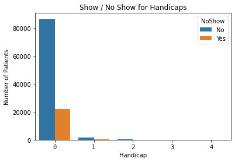

```python
# finding out the correlation between having handicaps and showing up for the appointment
chart_plot('Handicap', 'Show / No Show for Handicaps')
```

The patients who didn't have any handicaps were much more than The patients who have one handicap or more so it's normal that the patients who didn't have any handicaps were the most showed up for their appointment.

### Research Question 7 (Is there a correlation between gender and showing up for the appointment?)

By answering this question we will find if females were more likely to attend the appointment than males or the opposite or if gender doesn't affect attendance.

```python
# number of females and males who have taken appointment to attend
df.groupby('Gender').NoShow.count()
```

```
Gender
F    71832
M    38687
Name: NoShow, dtype: int64
```

We try to find out if the gender of patient affect in his attendance

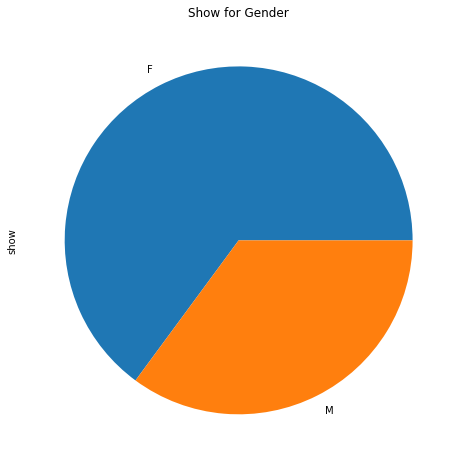

```python
# finding out the correlation between gender and showing up
df[show].Gender.value_counts().plot(kind='pie',figsize=(8,8), label='show')
plt.title('Show for Gender');
```

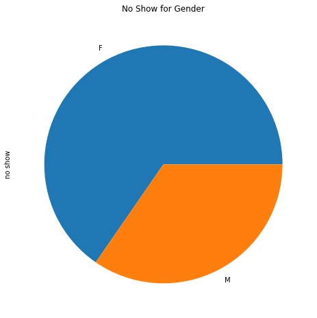

```python
# finding out the correlation between gender and not showing up
df[no_show].Gender.value_counts().plot(kind='pie', figsize=(8,8), label='no show')
plt.title('No Show for Gender');
```

females are more than males in either showing up or not showing up.

### Research Question 8 (Is age affect in showing up for the appointment?)

By answering this question we will discover if age would be a reason for showing or not showing.

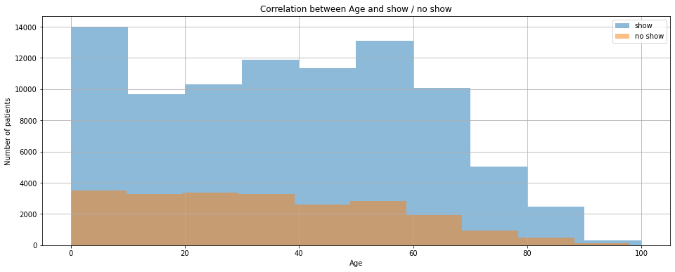

```python
# finding out the correlation between the age and showing up for the appointment
plt.figure(figsize=[16, 6])
df.Age[show].hist(alpha=0.5, label='show')
df.Age[no_show].hist(alpha=0.5, label='no show')
plt.title('Correlation between Age and show / no show')
plt.xlabel('Age')
plt.ylabel('Number of patients')
plt.legend();
```

Clearly from the visualization we made, patients who have from 0 to 10 and from 50 to 60 are the most attended patients, on the other hand, patients who have 65 years old or more are the least attended the appointment.

### Research Question 9 (Is age and having diseases affect in showing up for the appointment?)

By answering this question we will discover if being old and having some diseases would cause not showing up for the appointment.

```python
df[show].groupby(['Hypertension', 'Diabetes']).mean()['Age']
```

```
Hypertension  Diabetes
0             0           31.507180
              1           53.666952
1             0           59.697784
              1           63.406361
Name: Age, dtype: float64
```

```python
df[no_show].groupby(['Hypertension', 'Diabetes']).mean()['Age']
```

```
Hypertension  Diabetes
0             0           28.819995
              1           49.183391
1             0           58.377043
              1           62.820333
Name: Age, dtype: float64
```

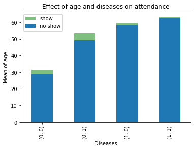

```python
# finding out the effect of age and having diseases on showing up for the appointment
df[show].groupby(['Hypertension', 'Diabetes']).mean()['Age'].plot(kind='bar', color='green', alpha=0.5, label='show')
df[no_show].groupby(['Hypertension', 'Diabetes']).mean()['Age'].plot(kind='bar', label='no show')
plt.xlabel('Diseases')
plt.ylabel('Mean of age')
plt.title('Effect of age and diseases on attendance')
plt.legend();
```

### Research Question 10 (Is age and having handicaps affect in showing up for the appointment?)

By answering this question we will discover if being old and having one or more handicaps would cause not showing up for the appointment.

```python
df[show].groupby('Handicap').mean()['Age']
```

```
Handicap
0    37.504064
1    51.686567
2    45.095890
3    53.400000
4    17.000000
Name: Age, dtype: float64
```

```python
df[no_show].groupby('Handicap').mean()['Age']
```

```
Handicap
0    34.068729
1    46.311295
2    58.351351
3    32.666667
4     9.000000
Name: Age, dtype: float64
```

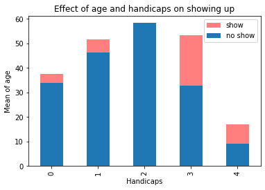

```python
# finding out the effect of age and having handicaps on showing up for the appointment
df[show].groupby('Handicap').mean()['Age'].plot(kind='bar', color='red', alpha=0.5, label='show')
df[no_show].groupby('Handicap').mean()['Age'].plot(kind='bar', label='no show')
plt.xlabel('Handicaps')
plt.ylabel('Mean of age')
plt.title('Effect of age and handicaps on showing up')
plt.legend();
```

## Conclusions

The result I get from my analysis:

The patients who had not a scholarship showed up for the appointment than those who had it so having a scholarship doesn't affect showing up for the appointment.

The number of patients who showed up and didn't have hypertension was more than the number of patients who showed up and have hypertension but also we have to consider that the number of patients who did have not hypertension was almost 4 times the number of patients who have hypertension so having hypertension doesn't affect showing up for the appointment.

The number of patients who showed up and didn't have diabetes was much more than the number of patients who showed up and have diabetes but also we have to consider that the number of patients who did have not diabetes was about 13 times the number of patients who have diabetes so having diabetes doesn't affect showing up for the appointment.

The number of patients who showed up and were not drinking alcoholism was much more than the number of patients who showed up and were drinking alcoholism but also we have to consider that the number of patients who were not drinking alcoholism was about 32 times the number of patients who were drinking alcoholism so drinking alcoholism doesn't affect showing up for the appointment.

The patients who didn't have any handicaps were much more than The patients who have one handicap or more so it's normal that the patients who didn't have any handicaps were the most showed up for their appointment so having handicaps doesn't affect showing up for the appointment.

Females are more than males in either showing up or not showing up so we can not say that gender affect showing up for the appointment.

Patients who have from 0 to 10 and from 50 to 60 were the most attended patients, on the other hand, patients who have 65 years old and more are the least attended the appointment. maybe we can say that patients who have 65 years old and more are likely to not attend the appointment but we can not say that age has that effect on showing up for the appointment.

## Limitations

In my analysis I didn't consider the appointment day.

The data has to include more information about the appointment, its type, the time that the appointment takes to end that may effect on showing up.